# Practical Machine Learning Coursera Project

Carlos Teles

## Summary

The goal of this project is to predict the manner in which a group of enthusiasts did exercises. The data consists of wearable sensors measurements of that group who take measurements about themselves regularly.

## Data Setup

Loading required packages and reading the dataset:

```r
library(caret)
library(gbm)

data1 = read.csv("D:pml-training.csv")
testing = read.csv("D:pml-testing.csv")
```

## Partitioning the training set

In order to estimate the Accuracy of the model, I will randomly split data into two parts, the training sample with 70% of observations and the validation sample, like this:

```r
set.seed(123)

ind<-createDataPartition(y=data1$classe,p=0.7,list=FALSE)

training<-data1[ind,]

validation<-data1[-ind,]
```

# Feature selection

Selecting features with too much(more then 50% of presence) NA,empty or error value(#DIV/0!)

```r
del<-1

for (i in 1:ncol(training)) {

  a<-sum( ifelse( is.na(training[,i]) | training[,i]=='' |training[,i]==c('#DIV/0!')   ,1,0 )/nrow(training))

  #considering to remove a > 50%
  if(a>0.5){

    del<-append(del,colnames(training)[i])

          }

                            }

training_cl<-training[ , !(names(training) %in% del)]
```

training_cl has only 60 of the 159 features, let’s check if it is possible to reduce even more this number using nearZeroVar to check nearly zero variance.

```r
nsv<-nearZeroVar(training_cl,saveMetrics=TRUE)

nsv
```

```
##                      freqRatio percentUnique zeroVar   nzv
## X                     1.000000  100.00000000   FALSE FALSE
## user_name             1.110114    0.04367766   FALSE FALSE
## raw_timestamp_part_1  1.000000    6.09303341   FALSE FALSE
## raw_timestamp_part_2  1.000000   89.48096382   FALSE FALSE
## cvtd_timestamp        1.014409    0.14559220   FALSE FALSE
## new_window           46.532872    0.01455922   FALSE  TRUE
## num_window            1.000000    6.24590522   FALSE FALSE
## roll_belt             1.034375    8.08764650   FALSE FALSE
## pitch_belt            1.204918   12.17150761   FALSE FALSE
## yaw_belt              1.077348   13.15425493   FALSE FALSE
## total_accel_belt      1.077358    0.21110868   FALSE FALSE
## gyros_belt_x          1.072034    0.92451045   FALSE FALSE
## gyros_belt_y          1.153819    0.46589503   FALSE FALSE
## gyros_belt_z          1.064205    1.20113562   FALSE FALSE
## accel_belt_x          1.068519    1.17201718   FALSE FALSE
## accel_belt_y          1.122109    0.99730654   FALSE FALSE
## accel_belt_z          1.055921    2.11836646   FALSE FALSE
## magnet_belt_x         1.108871    2.21300138   FALSE FALSE
## magnet_belt_y         1.103604    2.08196841   FALSE FALSE
## magnet_belt_z         1.002924    3.15207105   FALSE FALSE
## roll_arm             47.560000   17.36186940   FALSE FALSE
## pitch_arm            76.741935   20.28827255   FALSE FALSE
## yaw_arm              30.487179   19.10897576   FALSE FALSE
## total_accel_arm       1.079872    0.48045425   FALSE FALSE
## gyros_arm_x           1.010753    4.61527262   FALSE FALSE
## gyros_arm_y           1.490411    2.66433719   FALSE FALSE
## gyros_arm_z           1.056848    1.70342870   FALSE FALSE
## accel_arm_x           1.133929    5.57618112   FALSE FALSE
## accel_arm_y           1.165605    3.79995632   FALSE FALSE
## accel_arm_z           1.068182    5.60529956   FALSE FALSE
## magnet_arm_x          1.101695    9.65276261   FALSE FALSE
## magnet_arm_y          1.016129    6.22406639   FALSE FALSE
## magnet_arm_z          1.012987    9.11407149   FALSE FALSE
## roll_dumbbell         1.009804   86.31433355   FALSE FALSE
## pitch_dumbbell        2.000000   84.32700007   FALSE FALSE
## yaw_dumbbell          1.133333   85.69556672   FALSE FALSE
## total_accel_dumbbell  1.074816    0.30574361   FALSE FALSE
## gyros_dumbbell_x      1.006961    1.71070831   FALSE FALSE
## gyros_dumbbell_y      1.286064    1.92181699   FALSE FALSE
## gyros_dumbbell_z      1.058962    1.43408313   FALSE FALSE
## accel_dumbbell_x      1.031111    2.95552158   FALSE FALSE
## accel_dumbbell_y      1.052023    3.27582442   FALSE FALSE
## accel_dumbbell_z      1.159509    2.89728471   FALSE FALSE
## magnet_dumbbell_x     1.068376    7.78918250   FALSE FALSE
## magnet_dumbbell_y     1.257812    6.02023732   FALSE FALSE
## magnet_dumbbell_z     1.021429    4.79726287   FALSE FALSE
## roll_forearm         11.118367   13.62742957   FALSE FALSE
## pitch_forearm        61.886364   18.99978161   FALSE FALSE
## yaw_forearm          16.106509   12.90674820   FALSE FALSE
## total_accel_forearm   1.088664    0.50229308   FALSE FALSE
## gyros_forearm_x       1.074792    2.06012958   FALSE FALSE
## gyros_forearm_y       1.029412    5.24859868   FALSE FALSE
## gyros_forearm_z       1.137313    2.14020528   FALSE FALSE
## accel_forearm_x       1.047619    5.67809565   FALSE FALSE
## accel_forearm_y       1.000000    7.11217879   FALSE FALSE
## accel_forearm_z       1.185185    4.04746306   FALSE FALSE
## magnet_forearm_x      1.000000   10.61367111   FALSE FALSE
## magnet_forearm_y      1.163934   13.37264323   FALSE FALSE
## magnet_forearm_z      1.000000   11.84392517   FALSE FALSE
## classe                1.469526    0.03639805   FALSE FALSE
```

## Throwing non-informative features:

From nsv we can conclude that variable X is non-informative, so:

```r
training_cl$X<-NULL
```

new_window is nzv and has only 2% of yes:

```r
# minus 1 beacuse of the training_cl$X<-NULL
prop.table(summary(training_cl[,which(nsv$nzv)-1]))*100
```

```
##        no       yes
## 97.896193  2.103807
```

new_window is nzv, however I’m not confortable to throw this variable out, only nzv=TRUE not necessatily means that this predictor is non-informative.

Checking correlation between features (numeric ones):

```r
correlation<-abs(cor(training_cl[,unlist(lapply(training_cl, is.numeric))]))

diag(correlation) <- 0

sum(ifelse(correlation>0.8,1,0))
```

```
## [1] 38
```

As you can see there is 38 strong correlations, so might be a good idea to use PCA preprocessing.

## Model Building

I will build a model using gbm because is a robust algorithm if correctly tunned. The model will fit on the training sample(training_cl) and predict on the training and validation samples. The Accuracy will be measured and used as a error metric. I will use a 3-fold cross-validation and a alternative Tuning Grids.

In the trainControl I will change the default value of threshold to 0.8, and in the grid I will increase the range values of n.tree and interaction depth in order to select the optimal parameters.

```r
fitControl <- trainControl(method = "cv",
                           number = 3,
                           preProcOptions = list(thresh = 0.8))

gbmGrid <-  expand.grid(interaction.depth = seq(9,21,4),
                        n.trees =  seq(200,900,10) ,
                        shrinkage = c(0.1),
                        n.minobsinnode=10
                        )


set.seed(321)


training_cl$class<-NULL

gbmFit <- train(classe ~ .,method="gbm",
                data=training_cl,
                trControl=fitControl,
                metric="Accuracy",
                tuneGrid = gbmGrid,
                preProc="pca",
                 verbose = FALSE
                )
```

# Model Evaluation

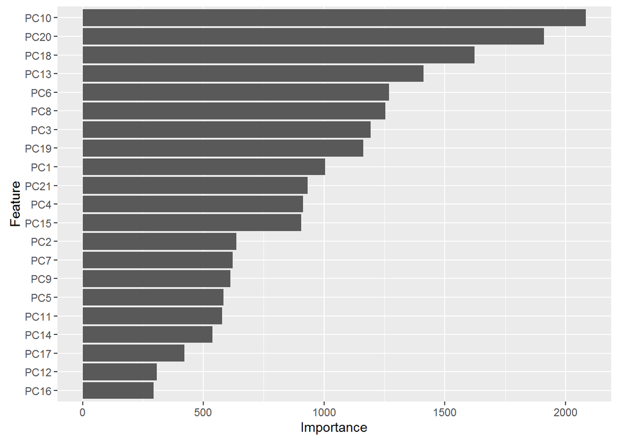

```r
ggplot(varImp(gbmFit, scale = FALSE))
```

Unfortunately my hardware can’t handle more trees, however the choosen parameters are enough to achive a relativilly high Accuracy.

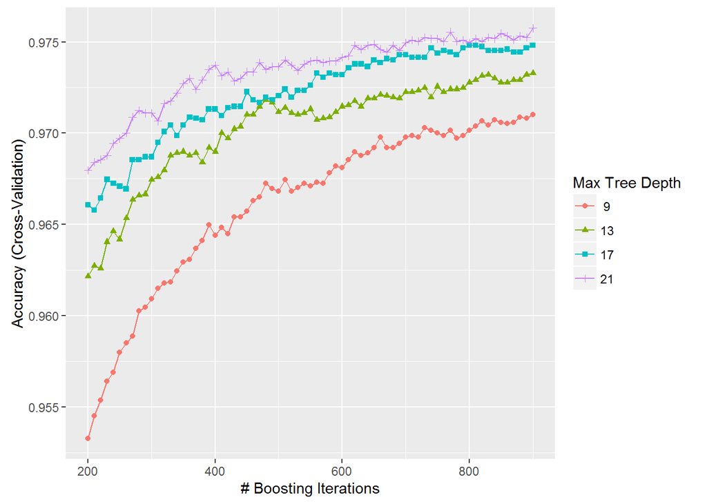

```r
ggplot(gbmFit)
```

From this graphic and from the gbmFit is possible to check the choosen parameters. The final values used for the model were n.trees = 900 and interaction.depth = 21. This big number of trees helps to avoid overfiting, on the other hand the predictors have to be informative to really avoid overfiting.

# In-sample accuracy

```r
pred_in <- predict(gbmFit, training_cl)

confusionMatrix(pred_in, training_cl$classe)
```

```
## Confusion Matrix and Statistics
##
##           Reference
## Prediction    A    B    C    D    E
##          A 3906    0    0    0    0
##          B    0 2658    0    0    0
##          C    0    0 2396    0    0
##          D    0    0    0 2252    0
##          E    0    0    0    0 2525
##
## Overall Statistics
##
##                Accuracy : 1
##                  95% CI : (0.9997, 1)
##     No Information Rate : 0.2843
##     P-Value [Acc > NIR] : < 2.2e-16
##
##                   Kappa : 1
##  Mcnemar's Test P-Value : NA
##
## Statistics by Class:
##
##                      Class: A Class: B Class: C Class: D Class: E
## Sensitivity            1.0000   1.0000   1.0000   1.0000   1.0000
## Specificity            1.0000   1.0000   1.0000   1.0000   1.0000
## Pos Pred Value         1.0000   1.0000   1.0000   1.0000   1.0000
## Neg Pred Value         1.0000   1.0000   1.0000   1.0000   1.0000
## Prevalence             0.2843   0.1935   0.1744   0.1639   0.1838
## Detection Rate         0.2843   0.1935   0.1744   0.1639   0.1838
## Detection Prevalence   0.2843   0.1935   0.1744   0.1639   0.1838
## Balanced Accuracy      1.0000   1.0000   1.0000   1.0000   1.0000
```

# Out-of-sample accuracy

```r
pred_out <- predict(gbmFit, validation)

confusionMatrix(pred_out, validation$classe)
```

```
## Confusion Matrix and Statistics
##
##           Reference
## Prediction    A    B    C    D    E
##          A 1665   18    0    0    0
##          B    4 1113   15    0    0
##          C    5    8 1008   21    0
##          D    0    0    3  942    3
##          E    0    0    0    1 1079
##
## Overall Statistics
##
##                Accuracy : 0.9867
##                  95% CI : (0.9835, 0.9895)
##     No Information Rate : 0.2845
##     P-Value [Acc > NIR] : < 2.2e-16
##
##                   Kappa : 0.9832
##  Mcnemar's Test P-Value : NA
##
## Statistics by Class:
##
##                      Class: A Class: B Class: C Class: D Class: E
## Sensitivity            0.9946   0.9772   0.9825   0.9772   0.9972
## Specificity            0.9957   0.9960   0.9930   0.9988   0.9998
## Pos Pred Value         0.9893   0.9832   0.9674   0.9937   0.9991
## Neg Pred Value         0.9979   0.9945   0.9963   0.9955   0.9994
## Prevalence             0.2845   0.1935   0.1743   0.1638   0.1839
## Detection Rate         0.2829   0.1891   0.1713   0.1601   0.1833
## Detection Prevalence   0.2860   0.1924   0.1771   0.1611   0.1835
## Balanced Accuracy      0.9952   0.9866   0.9877   0.9880   0.9985
```